# ΜΙΣΤΑ002: McNemar test

## McNemar test

Paired categorical measurements taken from the same participants on two occasions (before-after studies, cross-over trials) or matched categorical data collected in matched case – control studies must be analyzed using tests for correlated data. The measurements collected in these types of study designs are not independent and therefore chi-square test cannot be used because the assumptions would be violated. In this situation, McNemar’s test, for 2x2 tables, is used to assess whether there is a significant change in proportions over time for paired data or whether there is a significant difference in proportions between matched cases and controls. In this type of analysis, the outcome of interest is the within person changes or the within-pair differences and there are no explanatory variables. Examples for McNemar’s test study designs are shown in the following 2x2 cross-tabulation tables:

**Study design for before-after studies** **Study design for matched case-control studies**

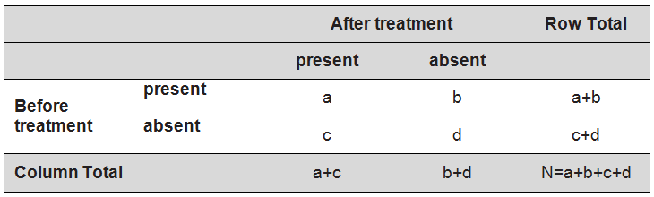

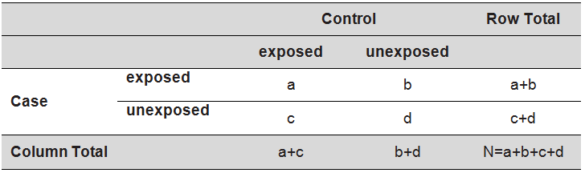

**Assumptions**

- The sample data have been randomly selected and consist of matched pairs.
- Large samples and b+c>25 (in the case that b+c<25, the exact binomial probability should be computed).

**Steps for conducting the test**

**Step 1. Define the null and alternative hypotheses under study**

**H<sub>0</sub>**: The two marginal probabilities for each outcome are the same, p<sub>a</sub> + p<sub>b</sub> = p<sub>a</sub> + p<sub>c</sub> and p<sub>c</sub> + p<sub>d</sub> = p<sub>b</sub> + p<sub>d</sub> which means that p<sub>b</sub> = p<sub>c</sub>.

**H<sub>1</sub>**: The two marginal probabilities for each outcome are not the same, p<sub>a</sub> + p<sub>b</sub> ≠p<sub>a</sub> + p<sub>c</sub> and p<sub>c</sub> + p<sub>d</sub> ≠ p<sub>b</sub> + p<sub>d</sub> which means that p<sub>b</sub>≠ p<sub>c</sub>.

**The null hypothesis in practice**

- The null hypothesis for before-after data is that the proportion of subjects with the characteristic is the same before and after treatment p<sub>a+b</sub>= p<sub>a+c</sub>.
- The null hypothesis for case-control pair matched data is that the proportion of subjects exposed to the risk factor is equal for cases and controls p<sub>a+b</sub> = p<sub>a+c</sub>.

Cells b and c are called the discordant cells because they represent pairs with a difference and must be b + c> 25. Cells a and d are the concordant cells, do not contribute any information about a difference between pairs or over time, so they aren’t used to calculate the test statistic. (**Note:** Mathematically speaking, the McNemar's test is undefined when b =c =0)

**On continuity correction for small samples**

Some authors recommend a version of McNemar’s test with a correction for continuity in the case of small samples but this is controversial. Since software now makes exact binomial probability feasible this correction is no longer needed.

**Step 3. Compare the value of the test statistic to values from the χ<sup>2</sup>- distribution**

**Step 4. Interpretation**

Interpretation of the results.

**Worked Example**

[figure not shown]

In a survey 86 children with asthma attended a camp to learn how to self-manage their asthmatic episodes. The children were asked whether they knew how to manage their asthmatic episodes appropriately at both the start and completion of the camp (the results are shown to the below table). Was a significant change in children's knowledge of asthma management between the beginning and completion of the health camp (a=0.05)?

**Summary of data in a 2x2 cross-tabulation table**

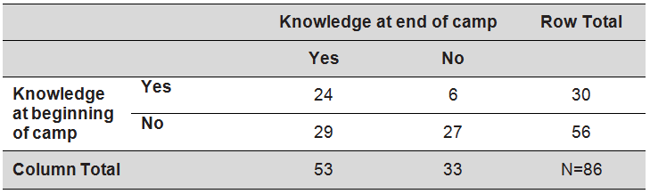

**Step 3. Compare the value of the test statistic to values from the χ<sup>2</sup>-distribution**  
The critical value of chi-square distribution for a=0.05 and df=1 is 3.84. **In this example, H<sub>0</sub> is rejected because χ<sup>2</sup>=**15.11**>3.84 (p<0.05).**  
**Step 4. Interpretation**

In the cross-tabulation table, the total row and total column cells indicate that (30/86)x100=34.9% of children had appropriate knowledge at the beginning of the camp and (53/86)x100=61.6% at the end of the camp. The analysis show that the number of children who knew how to manage their asthma episodes appropriately increased significantly on completion of the camp.

Last modified: Wednesday, 13 May 2020, 4:07 PM